# Notebook

## Diego Emilio Muñiz Ramirez #621784 - A1.1 Aprendizaje estadístico-automático

## 1. Importación del conjunto de datos

Se importó la base de datos la cual es “A1.1 Obesidad.csv” utilizando Python y la biblioteca pandas como bien se ve en el código. La base de datos contiene información demográfica, hábitos alimenticios y variables relacionadas con la salud de individuos así como su nivel de obesidad.

```python
import pandas as pd

df = pd.read_csv("A1.1 Obesidad.csv")
```

## 2. Exploración inicial de los datos

Se realizó una exploración inicial del conjunto de datos para comprender su estructura, tamaño y tipos de variables incluidas.

```python
df.head()
```

|  | Sexo | Edad | Estatura | Peso | FamiliarConSobrepeso | ComeMuchasCalorias | ComeVegetales | Fumador | ConsumoDeAgua | NivelDeObesidad |
| --- | --- | --- | --- | --- | --- | --- | --- | --- | --- | --- |
| 0 | Female | 21.0 | 1.62 | 64.0 | yes | no | 2.0 | no | 2.0 | Normal_Weight |
| 1 | Female | 21.0 | 1.52 | 56.0 | yes | no | 3.0 | yes | 3.0 | Normal_Weight |
| 2 | Male | 23.0 | 1.80 | 77.0 | yes | no | 2.0 | no | 2.0 | Normal_Weight |
| 3 | Male | 27.0 | 1.80 | 87.0 | no | no | 3.0 | no | 2.0 | Overweight_Level_I |
| 4 | Male | 22.0 | 1.78 | 89.8 | no | no | 2.0 | no | 2.0 | Overweight_Level_II |

```python
df.shape
```

```
(2111, 10)
```

```python
df.info()
```

```
<class 'pandas.core.frame.DataFrame'>
RangeIndex: 2111 entries, 0 to 2110
Data columns (total 10 columns):
 #   Column                Non-Null Count  Dtype
---  ------                --------------  -----
 0   Sexo                  2111 non-null   object
 1   Edad                  2111 non-null   float64
 2   Estatura              2111 non-null   float64
 3   Peso                  2111 non-null   float64
 4   FamiliarConSobrepeso  2111 non-null   object
 5   ComeMuchasCalorias    2111 non-null   object
 6   ComeVegetales         2111 non-null   float64
 7   Fumador               2111 non-null   object
 8   ConsumoDeAgua         2111 non-null   float64
 9   NivelDeObesidad       2111 non-null   object
dtypes: float64(5), object(5)
memory usage: 165.1+ KB
```

El conjunto de datos incluye variables cuantitativas como edad, estatura y peso, así como variables cualitativas relacionadas con hábitos alimenticios, consumo de agua, tabaquismo y nivel de obesidad. La base de datos presenta información consistente y no se observan valores faltantes relevantes.

## 3. Análisis descriptivo de variables numéricas

Aqui se calcularon estadísticas descriptivas para las variables numéricas con la finalidad de identificar sus valores promedio, rangos y dispersión. Estas medidas permiten obtener una visión general de las características físicas de la población analizada.

```python
df.describe()
```

|  | Edad | Estatura | Peso | ComeVegetales | ConsumoDeAgua |
| --- | --- | --- | --- | --- | --- |
| count | 2111.000000 | 2111.000000 | 2111.000000 | 2111.000000 | 2111.000000 |
| mean | 24.312600 | 1.701677 | 86.586058 | 2.419043 | 2.008011 |
| std | 6.345968 | 0.093305 | 26.191172 | 0.533927 | 0.612953 |
| min | 14.000000 | 1.450000 | 39.000000 | 1.000000 | 1.000000 |
| 25% | 19.947192 | 1.630000 | 65.473343 | 2.000000 | 1.584812 |
| 50% | 22.777890 | 1.700499 | 83.000000 | 2.385502 | 2.000000 |
| 75% | 26.000000 | 1.768464 | 107.430682 | 3.000000 | 2.477420 |
| max | 61.000000 | 1.980000 | 173.000000 | 3.000000 | 3.000000 |

```python
df.describe(include="object")
```

|  | Sexo | FamiliarConSobrepeso | ComeMuchasCalorias | Fumador | NivelDeObesidad |
| --- | --- | --- | --- | --- | --- |
| count | 2111 | 2111 | 2111 | 2111 | 2111 |
| unique | 2 | 2 | 2 | 2 | 7 |
| top | Male | yes | yes | no | Obesity_Type_I |
| freq | 1068 | 1726 | 1866 | 2067 | 351 |

## 4. Variable de interés para inferencia

Seleccioné el nivel de obesidad como variable de salida del estudio ya que representa el principal fenómeno de interés. Esta variable es categórica y clasifica a los individuos en distintos niveles de peso corporal.

```python
df["NivelDeObesidad"].value_counts()
```

| NivelDeObesidad | count |
| --- | --- |
| Obesity_Type_I | 351 |
| Obesity_Type_III | 324 |
| Obesity_Type_II | 297 |
| Overweight_Level_I | 290 |
| Overweight_Level_II | 290 |
| Normal_Weight | 287 |
| Insufficient_Weight | 272 |

**dtype:** int64

## 5. Análisis gráfico por subpoblación

Se seleccionó la subpoblación masculina para analizar la relación entre la edad y el peso corporal mediante una gráfica de dispersión.

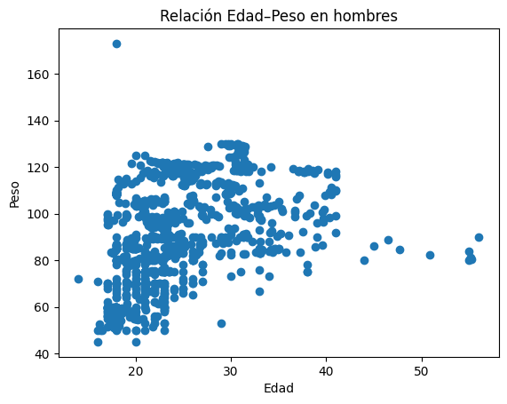

```python
import matplotlib.pyplot as plt

hombres = df[df["Sexo"] == "Male"]

plt.scatter(hombres["Edad"], hombres["Peso"])
plt.xlabel("Edad")
plt.ylabel("Peso")
plt.title("Relación Edad–Peso en hombres")
plt.show()
```

La gráfica muestra una alta dispersión del peso corporal a diferentes edades lo que indica que el peso no depende únicamente de la edad. Esto sugiere que otros factores como hábitos alimenticios y estilo de vida, influyen en el nivel de obesidad.

## Conclusión

Para finalizar esta actividad puedo decir que el análisis exploratorio permitió comprender la estructura del conjunto de datos y analizar la relación entre distintas variables asociadas a la obesidad. Los resultados sugieren que el nivel de obesidad está influenciado por múltiples factores por lo que un análisis inferencial más profundo podría aportar conclusiones relevantes.